# Advanced `ggplot2` Homework - Answers

# Learning Objectives

- Practice making plots with ggplot2
- Create your own theme and use it with plots

# Background

QikBit is a start-up company producing low cost fitness trackers. Their flagship product, the KwikBit Unit1 (spot the mistake on the patent form) reproduces the functionality of the best-in-class commercial fitness trackers, but is cheap to make. They are currently preparing to pitch to a potential investor and require a selection of charts to include in their presentation and promotional materials.

# Data

The data for this assignment is provided in the `CodeClanData` package.

- `qb_revenue_breakdown`
- `qb_monthly_sales`
- `qb_competitors`
- `qb_device_data`

Take a little time before you start to familiarise yourself with the data.

```r
library(tidyverse)
library(CodeClanData)
library(scales)
head(qb_revenue_breakdown)
```

|  | Product | Year | Revenue |
| --- | --- | --- | --- |
| 1 | Trackers | 2019 | 8994 |
| 2 | Smart Watches | 2019 | 12003 |
| 3 | Accessories | 2019 | 5250 |
| 4 | Subscription Services | 2019 | 3750 |
| 5 | Trackers | 2018 | 8004 |
| 6 | Smart Watches | 2018 | 11000 |

```r
head(qb_monthly_sales)
```

|  | Date | Cashflow | Amount |
| --- | --- | --- | --- |
| 1 | 2019-07-01 | Kwikbit Unit 1 Sales | 601.74 |
| 2 | 2019-06-01 | Kwikbit Unit 1 Sales | 567.89 |
| 3 | 2019-05-01 | Kwikbit Unit 1 Sales | 536.00 |
| 4 | 2019-04-01 | Kwikbit Unit 1 Sales | 550.78 |
| 5 | 2019-03-01 | Kwikbit Unit 1 Sales | 526.03 |
| 6 | 2019-02-01 | Kwikbit Unit 1 Sales | 584.22 |

```r
head(qb_competitors)
```

|  | Company | Year | Revenue |
| --- | --- | --- | --- |
| 1 | Competitor 1 | 2019 | 2216000 |
| 2 | Competitor 2 | 2019 | 1760000 |
| 3 | Competitor 3 | 2019 | 1455000 |
| 4 | Competitor 4 | 2019 | 1229000 |
| 5 | Competitor 1 | 2018 | 2144400 |
| 6 | Competitor 2 | 2018 | 1440000 |

```r
head(qb_device_data)
```

|  | device | id | hours | mins | counts |
| --- | --- | --- | --- | --- | --- |
| 361 | qikbit1 | person1 | 6 | 0 | 0 |
| 362 | qikbit1 | person1 | 6 | 1 | 0 |
| 363 | qikbit1 | person1 | 6 | 2 | 0 |
| 364 | qikbit1 | person1 | 6 | 3 | 0 |
| 365 | qikbit1 | person1 | 6 | 4 | 0 |
| 366 | qikbit1 | person1 | 6 | 5 | 0 |

# MVP

## Part 1

1. Take the data in the dataset `qb_revenue_breakdown` and make a stacked bar chart showing the sources of revenue across the two years in the dataset.

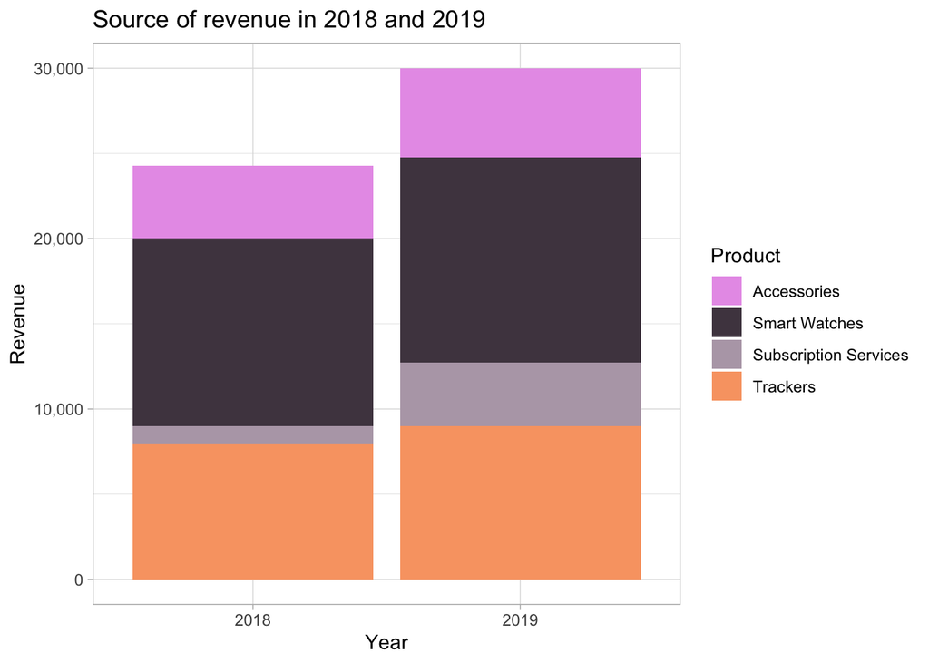

```r
ggplot(qb_revenue_breakdown) +
  aes(x = Year, y = Revenue, fill = Product) +
  geom_bar(position = "stack", stat = "identity") +
  theme_light() +
  scale_y_continuous(labels = scales::comma) +
  scale_fill_manual(
    values = c(
      "Accessories" = "#E89FE9",
      "Smart Watches" = "#50434F",
      "Subscription Services" = "#B6A7B5",
      "Trackers" = "#F9A472"
    )
  ) +
  labs(
    title = "Source of revenue in 2018 and 2019"
  )
```

2. Make a line chart showing monthly sales of the “flagship product” - the ‘KwikBit Unit 1’ - over the last year. This data is inside `qb_monthly_sales`, but you will need to use `filter()` or `subset()` (base `R)`.

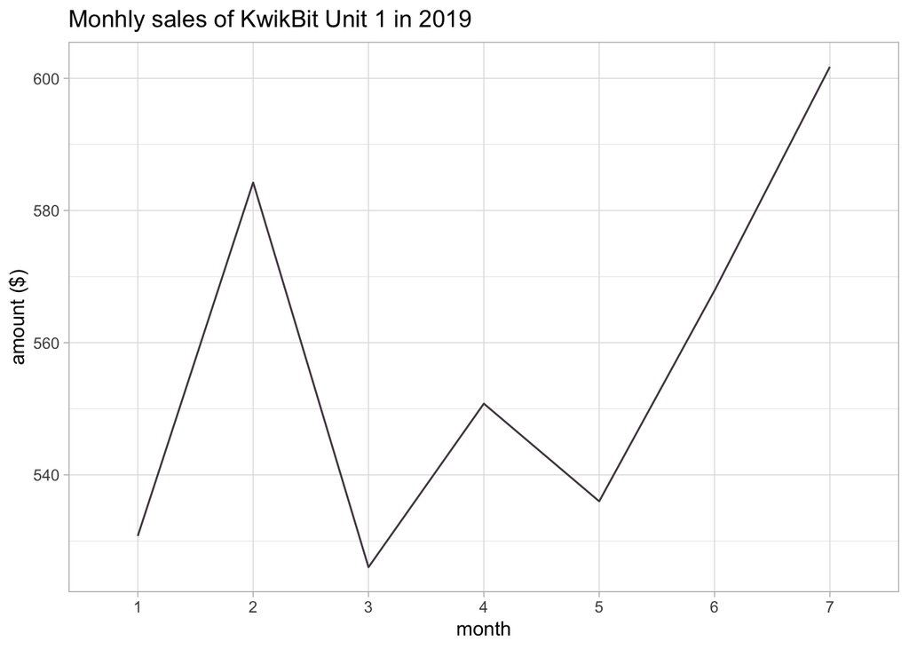

```r
qb_monthly_sales %>%
  filter(str_detect(as.character(Date), "2019")) %>%
  filter(Cashflow == "Kwikbit Unit 1 Sales") %>%
  separate(
    col = Date,
    into = c("year", "month"),
    sep = "-0"
  ) %>%
  ggplot() +
    aes(x = month, y = Amount, group = Cashflow, colour = Cashflow) +
    geom_line(colour = "#50434F") +
    theme_light() +
    labs(
      y = "amount ($)",
      title = "Monhly sales of KwikBit Unit 1 in 2019"
    )
```

3. Make a line chart showing monthly revenue and costs over the last year. This data is also in `qb_monthly_sales`.

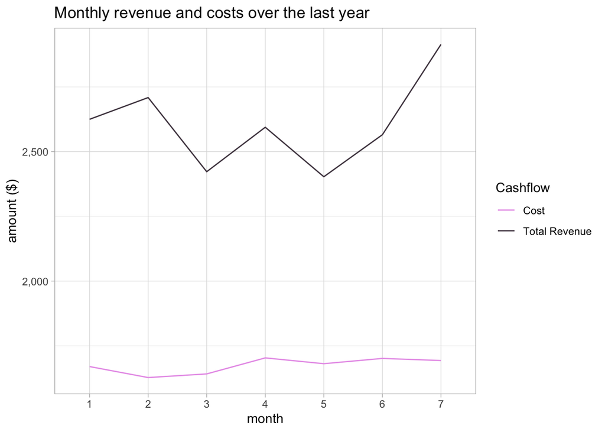

```r
qb_monthly_sales %>%
  filter(str_detect(as.character(Date), "2019")) %>%
  filter(Cashflow == "Total Revenue" | Cashflow == "Cost") %>%
  separate(
    col = Date,
    into = c("year", "month"),
    sep = "-0"
  ) %>%
  ggplot() +
    aes(x = month, y = Amount, group = Cashflow, colour = Cashflow) +
    geom_line() +
    theme_light() +
    scale_y_continuous(labels = scales::comma) +
    scale_colour_manual(
      values = c(
      "Cost" = "#E89FE9",
      "Total Revenue" = "#50434F")
    ) +
    labs(
      y = "amount ($)",
      title = "Monthly revenue and costs over the last year"
    )
```

4. Show annual sales of personal fitness trackers over the last 5 years broken down by company as a ribbon plot (use `geom_area`). This data is in `qb_competitors`.

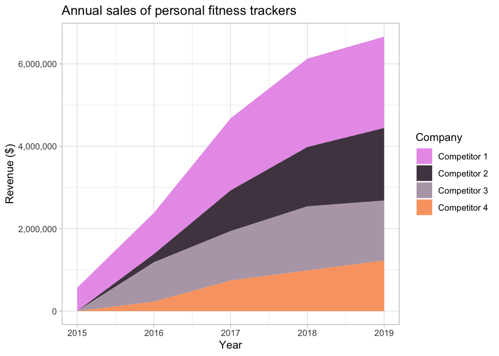

```r
ggplot(qb_competitors) +
  aes(x = Year, y = Revenue, group = Company, fill = Company) +
  geom_area() +
  scale_y_continuous(labels = scales::comma) +
  theme_light() +
  scale_fill_manual(
    values = c(
      "Competitor 1" = "#E89FE9",
      "Competitor 2" = "#50434F",
      "Competitor 3" = "#B6A7B5",
      "Competitor 4" = "#F9A472"
    )
  ) +
  labs(
    y = "Revenue ($)",
    title = "Annual sales of personal fitness trackers"
  )
```

5. Now show the sales from the four competitors as a line graph. Include an extra layer that shows the data points used to make the lines.

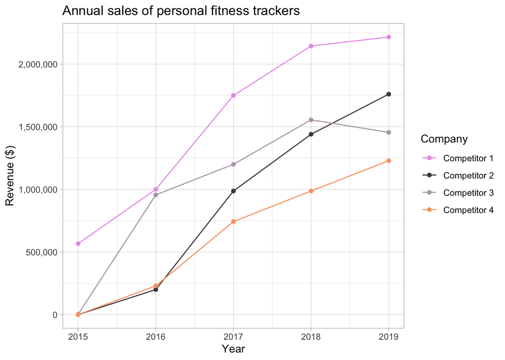

```r
ggplot(qb_competitors) +
  aes(x = Year, y = Revenue, group = Company, colour = Company) +
  geom_line() +
  geom_point() +
  scale_y_continuous(labels = scales::comma) +
  theme_light() +
  scale_colour_manual(
    values = c(
      "Competitor 1" = "#E89FE9",
      "Competitor 2" = "#50434F",
      "Competitor 3" = "#B6A7B5",
      "Competitor 4" = "#F9A472"
    )
  ) +
  labs(
    y = "Revenue ($)",
    title = "Annual sales of personal fitness trackers"
  )
```

6. Now the company wants to compare the number of steps that their device counts vs. their competitors. Make a line graph of the number of steps throughout time, and use faceting to compare between companies and people. The data for this is in `qb_device_data`.

```r
qb_device_data_hours <- qb_device_data %>%
  group_by(device, id, hours) %>%
  mutate(
    number_of_steps = sum(counts)
  ) %>%
  summarise(number_of_steps = sum(counts))
```

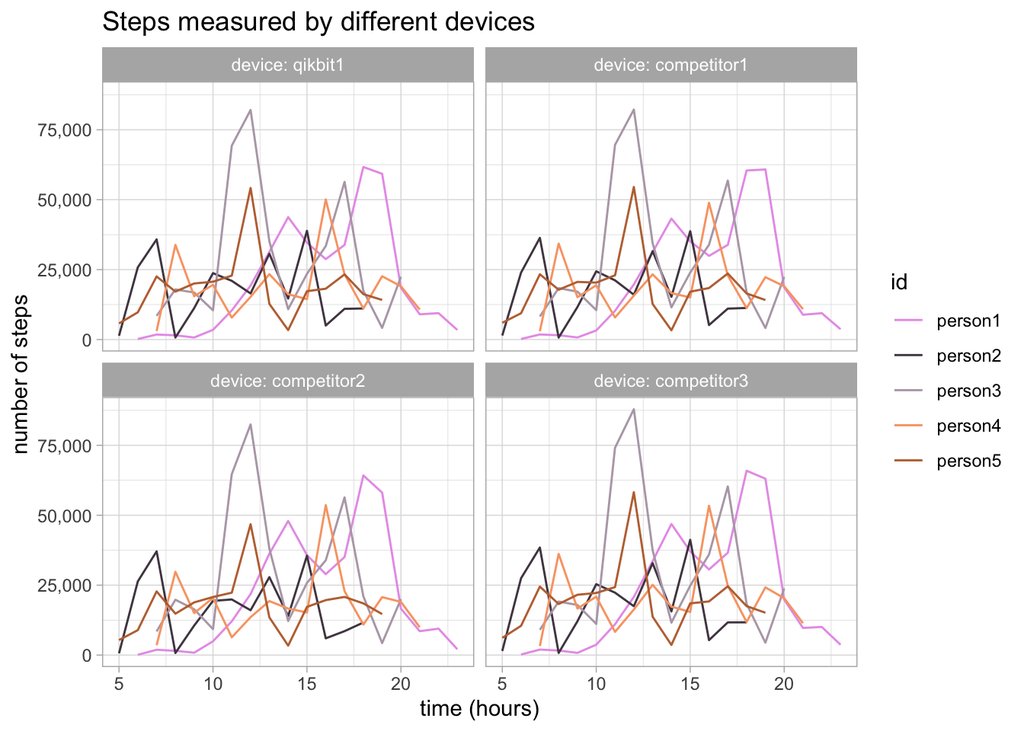

```r
ggplot(qb_device_data_hours) +
  aes(x = hours, y = number_of_steps, group = id, col = id) +
  geom_line() +
  facet_wrap(~ device, labeller = "label_both") +
  theme_light() +
  scale_y_continuous(labels = scales::comma) +
  scale_colour_manual(
    values = c(
      "person1" = "#E89FE9",
      "person2" = "#50434F",
      "person3" = "#B6A7B5",
      "person4" = "#F9A472",
      "person5" = "#BD7040"
    )
  ) +
  labs(
    x = "time (hours)",
    y = "number of steps",
    title = "Steps measured by different devices"
  )
```

```r
# First I created a new column 'number_of_steps' that summarises the number of steps in each hour, grouped by device and person.
# Then I plotted a line graph showing the number of steps over time and faceted it into four plots by devices.
# We are getting similar step counts across all four devices.
```

## Part 2

Take the plots that you produced in part one and now polish them by:

1. Adding appropriate labels
2. Changing the scales and coordinates when appropriate.
3. Applying a unified theme, which is described below:
- Graphs should have white backgrounds, and use colour sparingly.
- There should be faint grid lines.
- Font sizes should be ~12pt although titles should be slightly larger and axis labels can be slightly smaller.
- All plots should use colours from the following company colour scheme.

```r
col_scheme <- c("#E89FE9", "#50434F", "#B6A7B5", "#F9A472", "#BD7040")
```

# Extension

Try out different ways of plotting these three datasets. Which graphs do you think are particularly effective at showing QikBit’s success?